# Assingment1

Walter and Joan and Anna

2024-10-04

# Cancer Mortality Analysis

## Description

This project aims to analyse data from the famous “Cancer Mortality” open data set which contains over 3000 observations and 33 variables, included the target variable **target deathrate**.

We will follow a common data analysis pipeline:

```
Ingestion -> Cleaning -> Transformations -> EDA -> Feature Engineering -> Model selection -> evaluation
```

Credits: - Anna Monso - Joan Acero - Walter Troiani

## 1. Data Ingestion

```r
library(mice)
library(missMDA)
library(car)
setwd("~/Escritorio/College/Q9/SIM/ASSIGNMENT1")
test_df <- read.csv("test.csv",)
train_df <- read.csv("train.csv")

names(train_df)
```

```
##  [1] "avganncount"             "avgdeathsperyear"
##  [3] "target_deathrate"        "incidencerate"
##  [5] "medincome"               "popest2015"
##  [7] "povertypercent"          "studypercap"
##  [9] "binnedinc"               "medianage"
## [11] "medianagemale"           "medianagefemale"
## [13] "geography"               "percentmarried"
## [15] "pctnohs18_24"            "pcths18_24"
## [17] "pctsomecol18_24"         "pctbachdeg18_24"
## [19] "pcths25_over"            "pctbachdeg25_over"
## [21] "pctemployed16_over"      "pctunemployed16_over"
## [23] "pctprivatecoverage"      "pctprivatecoveragealone"
## [25] "pctempprivcoverage"      "pctpubliccoverage"
## [27] "pctpubliccoveragealone"  "pctwhite"
## [29] "pctblack"                "pctasian"
## [31] "pctotherrace"            "pctmarriedhouseholds"
## [33] "birthrate"
```

## 2. Variable analysis

```r
head(train_df)
```

```
##   avganncount avgdeathsperyear target_deathrate incidencerate medincome
## 1          57               26            144.4         350.1     49955
## 2         428              152            176.0         505.4     52313
## 3         146               71            183.6         404.0     40189
## 4        4025             1380            177.8         510.9     60397
## 5         113               36            121.4         413.3     54721
## 6         740              269            172.7         499.3     51395
##   popest2015 povertypercent studypercap          binnedinc medianage
## 1      10321           12.5      0.0000 (48021.6, 51046.4]      48.3
## 2      61023           15.6    180.2599 (51046.4, 54545.6]      45.4
## 3      20848           17.8      0.0000 (37413.8, 40362.7]      51.7
## 4     843954           13.1    427.7484 (54545.6, 61494.5]      35.8
## 5      16252           12.7      0.0000 (54545.6, 61494.5]      54.4
## 6     121846           15.7    837.1223 (51046.4, 54545.6]      41.0
##   medianagemale medianagefemale                   geography percentmarried
```

[output cut: 41 more lines]

The main *variables* we can see can be grouped in diferent parts.

- **Demographical Data**:
  - *Ages*:
    - `medianage` (Median age of the population)
    - `medianagemale` (Median age of males)
    - `medianagefemale` (Median age of females)
  - *Population*:
    - `popest2015` (Population estimate for 2015)
    - `birthrate` (Birth rate)
  - *Marital Status*:
    - `percentmarried` (Percentage of individuals married)
    - `pctmarriedhouseholds` (Percentage of married households)
  - *Racial Demographics*:
    - `pctwhite` (Percentage of White population)
    - `pctblack` (Percentage of Black population)
    - `pctasian` (Percentage of Asian population)
    - `pctotherrace` (Percentage of Other Races)
- **Economic Data**:
  - *Income*:
    - `medincome` (Median household income)
  - *Poverty*:
    - `povertypercent` (Percentage of population below the poverty line)
  - *Study Spending*:
    - `studypercap` (Per capita study spending)
  - *Binned Income*:
    - `binnedinc` (Income categorized into bins)
- **Geographical Data**:
  - `geography` (Represents U.S. counties)
- **Cancer Statistics**:
  - `avganncount` (Average annual cancer cases)
  - `avgdeathsperyear` (Average cancer-related deaths per year)
  - `target_deathrate` (Targeted death rate per 100,000 people)
  - `incidencerate` (Cancer incidence rate per 100,000 people)
- **Educational Data**:
  - *Education for Age 18-24*:
    - `pctnohs18_24` (Percentage with no high school education)
    - `pcths18_24` (Percentage with a high school diploma)
    - `pctsomecol18_24` (Percentage with some college education)
    - `pctbachdeg18_24` (Percentage with a bachelor’s degree)
  - *Education for Age 25 and Over*:
    - `pcths25_over` (Percentage with a high school diploma)
    - `pctbachdeg25_over` (Percentage with a bachelor’s degree)
- **Employment Data**:
  - `pctemployed16_over` (Percentage of population aged 16+ employed)
  - `pctunemployed16_over` (Percentage of population aged 16+ unemployed)
- **Healthcare Coverage**:
  - *Private Insurance*:
    - `pctprivatecoverage` (Percentage with any private coverage)
    - `pctprivatecoveragealone` (Percentage with private coverage only)
    - `pctempprivcoverage` (Percentage of employed population with private coverage)
  - *Public Insurance*:
    - `pctpubliccoverage` (Percentage with any public coverage)
    - `pctpubliccoveragealone` (Percentage relying solely on public coverage)

## 3. Data Cleaning

```r
summary(train_df)
```

```
##   avganncount      avgdeathsperyear  target_deathrate incidencerate
##  Min.   :    7.0   Min.   :    3.0   Min.   : 59.7    Min.   : 201.3
##  1st Qu.:   80.0   1st Qu.:   29.0   1st Qu.:161.3    1st Qu.: 421.4
##  Median :  175.0   Median :   62.0   Median :178.3    Median : 453.5
##  Mean   :  623.2   Mean   :  191.6   Mean   :178.8    Mean   : 449.0
##  3rd Qu.:  509.0   3rd Qu.:  140.5   3rd Qu.:195.3    3rd Qu.: 481.3
##  Max.   :38150.0   Max.   :14010.0   Max.   :362.8    Max.   :1206.9
##
##    medincome        popest2015       povertypercent   studypercap
##  Min.   : 22640   Min.   :     829   Min.   : 3.70   Min.   :   0.0
##  1st Qu.: 39031   1st Qu.:   12191   1st Qu.:12.15   1st Qu.:   0.0
##  Median : 45454   Median :   27158   Median :15.70   Median :   0.0
##  Mean   : 47278   Mean   :  106841   Mean   :16.79   Mean   : 148.2
##  3rd Qu.: 52612   3rd Qu.:   66880   3rd Qu.:20.40   3rd Qu.:  76.0
##  Max.   :122641   Max.   :10170292   Max.   :44.00   Max.   :9762.3
##
##   binnedinc           medianage      medianagemale   medianagefemale
##  Length:1831        Min.   : 23.30   Min.   :23.00   Min.   :23.60
##  Class :character   1st Qu.: 37.90   1st Qu.:36.40   1st Qu.:39.20
##  Mode  :character   Median : 40.90   Median :39.50   Median :42.40
##                     Mean   : 45.25   Mean   :39.59   Mean   :42.17
##                     3rd Qu.: 44.00   3rd Qu.:42.60   3rd Qu.:45.30
##                     Max.   :624.00   Max.   :60.20   Max.   :58.20
##
##   geography         percentmarried  pctnohs18_24     pcths18_24
##  Length:1831        Min.   :23.1   Min.   : 0.50   Min.   : 0.0
##  Class :character   1st Qu.:47.8   1st Qu.:12.90   1st Qu.:29.2
##  Mode  :character   Median :52.5   Median :17.20   Median :34.7
##                     Mean   :51.9   Mean   :18.29   Mean   :35.0
##                     3rd Qu.:56.4   3rd Qu.:22.70   3rd Qu.:40.5
##                     Max.   :68.0   Max.   :59.10   Max.   :72.5
##
##  pctsomecol18_24 pctbachdeg18_24   pcths25_over   pctbachdeg25_over
##  Min.   : 9.60   Min.   : 0.000   Min.   : 8.30   Min.   : 2.5
##  1st Qu.:33.25   1st Qu.: 3.200   1st Qu.:30.35   1st Qu.: 9.3
##  Median :40.10   Median : 5.400   Median :35.30   Median :12.3
##  Mean   :40.48   Mean   : 6.216   Mean   :34.73   Mean   :13.3
##  3rd Qu.:46.10   3rd Qu.: 8.200   3rd Qu.:39.65   3rd Qu.:16.0
##  Max.   :78.30   Max.   :51.800   Max.   :52.70   Max.   :42.2
##  NA's   :1376
```

[output cut: 17 more lines]

```
##  Min.   : 2.60          Min.   :12.27   Min.   : 0.000   Min.   : 0.0000
##  1st Qu.:14.90          1st Qu.:77.31   1st Qu.: 0.648   1st Qu.: 0.2582
##  Median :18.70          Median :89.90   Median : 2.323   Median : 0.5495
##  Mean   :19.15          Mean   :83.85   Mean   : 9.082   Mean   : 1.2743
##  3rd Qu.:23.00          3rd Qu.:95.57   3rd Qu.:10.867   3rd Qu.: 1.2515
##  Max.   :46.60          Max.   :99.69   Max.   :85.948   Max.   :37.1569
##
##   pctotherrace     pctmarriedhouseholds   birthrate
##  Min.   : 0.0000   Min.   :22.99        Min.   : 0.000
##  1st Qu.: 0.2867   1st Qu.:47.85        1st Qu.: 4.528
##  Median : 0.7826   Median :51.73        Median : 5.355
##  Mean   : 2.0031   Mean   :51.40        Mean   : 5.597
##  3rd Qu.: 2.1066   3rd Qu.:55.48        3rd Qu.: 6.414
##  Max.   :41.9303   Max.   :71.40        Max.   :21.326
##
```

### 3.1 Missing values & Imputation

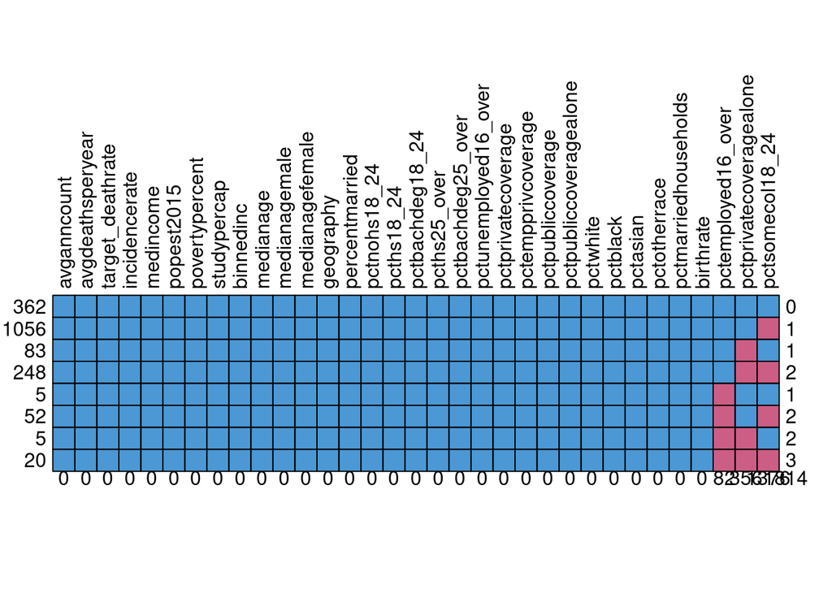

```
##      avganncount avgdeathsperyear target_deathrate incidencerate medincome
## 362            1                1                1             1         1
## 1056           1                1                1             1         1
## 83             1                1                1             1         1
## 248            1                1                1             1         1
## 5              1                1                1             1         1
## 52             1                1                1             1         1
## 5              1                1                1             1         1
## 20             1                1                1             1         1
##                0                0                0             0         0
##      popest2015 povertypercent studypercap binnedinc medianage medianagemale
## 362           1              1           1         1         1             1
## 1056          1              1           1         1         1             1
## 83            1              1           1         1         1             1
## 248           1              1           1         1         1             1
```

[output cut: 65 more lines]

```r
md.pattern(x=train_df, rotate.names=TRUE)
```

### 3.2 Outlier detection & handling

## 4. Data Transformations

## 5. Exploratory Data Analysis

## 6. Modeling

We are going to implement various linear models to predict the response variable: **target_deathrate**.

k-fold cross validation where k = 10 :)

## 7. Evaluation

## 8. Assesing final questions

Finally we need to asses some relevant statistical questions:

- Multicollinearity
- Normality of residual distribution
- Linearity of the model (Parameters)
- Serial independence of errors
- Heteroskedasticity